# Load Data

```python
import pandas as pd
df_CustomerBehavior = pd.read_csv('https://storage.googleapis.com/datalynn-datasets/interview-challenge/technology/Amazon_Ecom_Platform/df_CustomerBehavior.csv')
df_ProductReviews = pd.read_csv('https://storage.googleapis.com/datalynn-datasets/interview-challenge/technology/Amazon_Ecom_Platform/df_ProductReviews.csv')
```

## Question 1: **Data Cleaning & Exploration**

*Scenario:* You're handed the `CustomerBehavior` table. Before any analysis can be done, the data quality needs to be ensured. You suspect there might be some data issues.

1. Identify and address any missing values in the `CustomerBehavior` table.
2. Check for any outliers, especially in the `time_spent` column and devise a method to address them.
3. Ensure the `visit_date` is in a uniform date format.

**Hints**

1. **Identify and Address Missing Values**
   - Check for missing values in the entire `df_CustomerBehavior` dataframe.
   - Decide on a strategy for handling these missing values (remove or impute).
2. **Identify and Address Outliers in `time_spent`**
   - Use statistical methods or visualizations to identify outliers.
   - Decide on a strategy to handle these outliers (remove, impute, or cap).
3. **Ensure Uniform Date Format for `visit_date`**
   - Convert the `visit_date` column to a uniform datetime format using pandas.

```python
# 1. Identify and Address Missing Values
missing_values = df_CustomerBehavior.isnull().sum()
print(missing_values)

# Assuming we want to drop rows with missing values for simplicity (other imputation methods can be employed if needed)
df_CustomerBehavior.dropna(inplace=True)

# Confirm missing values have been addressed
print("\nAfter addressing missing values:")
print(df_CustomerBehavior.isnull().sum())
```

```
customer_id     0
visit_date     10
product_id      0
time_spent      0
action         20
dtype: int64

After addressing missing values:
customer_id    0
visit_date     0
product_id     0
time_spent     0
action         0
dtype: int64
```

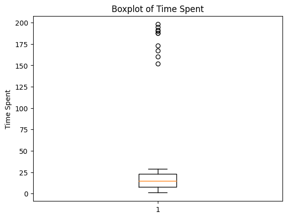

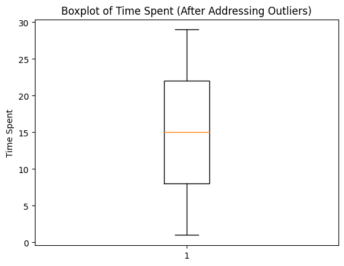

```python
# 2. Identify and Address Outliers in time_spent
import matplotlib.pyplot as plt

# Visualizing outliers using a boxplot
plt.boxplot(df_CustomerBehavior['time_spent'])
plt.title('Boxplot of Time Spent')
plt.ylabel('Time Spent')
plt.show()

# Assuming we use the IQR method to identify and handle outliers
Q1 = df_CustomerBehavior['time_spent'].quantile(0.25)
Q3 = df_CustomerBehavior['time_spent'].quantile(0.75)
IQR = Q3 - Q1

lower_bound = Q1 - 1.5 * IQR
upper_bound = Q3 + 1.5 * IQR

# Filter out outliers
df_CustomerBehavior = df_CustomerBehavior[(df_CustomerBehavior['time_spent'] >= lower_bound) &
                                          (df_CustomerBehavior['time_spent'] <= upper_bound)]

# Confirm the outliers have been addressed
plt.boxplot(df_CustomerBehavior['time_spent'])
plt.title('Boxplot of Time Spent (After Addressing Outliers)')
plt.ylabel('Time Spent')
plt.show()
```

```python
# 3. Ensure Uniform Date Format for visit_date
df_CustomerBehavior['visit_date'] = pd.to_datetime(df_CustomerBehavior['visit_date'], errors='coerce')

# Confirm the date format
print(df_CustomerBehavior['visit_date'].head())
```

```
0   2022-01-30 05:14:00
1   2021-10-18 21:17:00
2   2021-10-20 08:38:00
3   2020-09-01 00:03:00
4   2020-06-03 02:38:00
Name: visit_date, dtype: datetime64[ns]
```

## Question 2: **SQL Queries**

*Scenario:* With both `CustomerBehavior` and `ProductReviews` tables at your disposal, the marketing team wants insights into customers' engagement and their feedback.

1. Using a JOIN operation, retrieve a list of `customer_id`s who have both bought a product and written a review for it.
2. Using UNION, combine all unique `product_id`s from both tables.
3. Write a CTE to fetch the top 10 products with the highest average rating.

**Hints**

1. **Retrieve a list of customer_ids who have both bought a product and written a review for it.**
   - **Method**:
     - We'll JOIN the two tables on `product_id` and `customer_id`.
     - We'll filter out rows where the action is "Buy" from the `CustomerBehavior` table and where there's a valid `rating` in the `ProductReviews` table.
2. **Combine all unique product_ids from both tables.**
   - **Method**:
     - We'll use UNION to combine unique product_ids from both tables to ensure no duplicates.
3. **Fetch the top 10 products with the highest average rating.**
   - **Method**:
     - We'll use a Common Table Expression (CTE) to calculate average rating for each product.
     - Order by the average rating in descending order and limit the result to the top 10.

```python
import sqlite3

# Connect to SQLite database
conn = sqlite3.connect(':memory:')
df_CustomerBehavior.to_sql('CustomerBehavior', conn, if_exists='replace', index=False)
df_ProductReviews.to_sql('ProductReviews', conn, if_exists='replace', index=False)

query1 = """
    SELECT DISTINCT cb.customer_id
    FROM CustomerBehavior cb
    JOIN ProductReviews pr
    ON cb.customer_id = pr.customer_id AND cb.product_id = pr.product_id
    WHERE cb.action = 'Buy'
"""

customers = conn.execute(query1).fetchall()
print(customers)
```

```
[('2845d93d-0525-4cdd-b74d-f53253759278',), ('221efa45-d4f6-453f-a3ea-34cccb7bc70f',), ('22832b0f-de08-48e9-9245-62102125cc42',), ('6ce5b7d0-54b0-485a-b29d-94468adbfe63',), ('d921cb5c-2cfb-4e60-8539-1005a98a5e20',), ('9d4b71b8-db79-4d96-a3b1-f843c347bcca',), ('bad61dfe-2f0d-46fa-b803-5c47810307de',)…
```

```python
query2 = """
    SELECT product_id FROM CustomerBehavior
    UNION
    SELECT product_id FROM ProductReviews
"""

unique_products = conn.execute(query2).fetchall()
print(unique_products)
```

```
[('0076f646-9ddf-4f73-b928-537bd921dc63',), ('00af5013-8731-4d9d-9b4f-96c43e23b594',), ('01d7eba9-bef6-4660-a5bc-4a96cfd0e0e3',), ('0241f9ab-9c4b-4f32-b0b9-a0aaa3aed3ca',), ('024be7c7-eab9-46a9-85e8-368801b95fad',), ('02a94ac1-42fa-4d7f-9694-3fde55827d3e',), ('02c4fd4c-3ebe-489f-b12d-3fee6de116b4',)…
```

```python
query3 = """
    WITH AverageRating AS (
        SELECT product_id, AVG(rating) as avg_rating
        FROM ProductReviews
        GROUP BY product_id
    )

    SELECT product_id, avg_rating
    FROM AverageRating
    ORDER BY avg_rating DESC
    LIMIT 10
"""

top_products = conn.execute(query3).fetchall()
top_products
```

```
[('0523b376-d7ef-4e66-8e99-86a04b790d94', 5.0),
 ('09aeb09d-5fe9-4253-ac2f-6214c8c9bfde', 5.0),
 ('0fd70100-6999-49cb-b55a-3420e01cef37', 5.0),
 ('1906dc74-450d-4961-a23a-375893c1e069', 5.0),
 ('26de6250-f72b-4a2d-b269-6cd0c42a6d9b', 5.0),
 ('2ed0d438-c8eb-442f-96e4-a172a747acc5', 5.0),
 ('33d13de2-dbe9-4f20-9aa7-d9218321e95f', 5.0),
 ('3fdce3eb-826b-4c90-ac5e-c18da1490327', 5.0),
 ('43c00d97-4e41-4685-93db-15a3c6f38eff', 5.0),
 ('474f2aee-5b47-4d3d-b93b-75cce087a4e3', 5.0)]
```

## Question 3: **Probability and Statistical Analysis**

*Scenario:* Different categories of products may receive different average ratings. You want to determine if there's a statistically significant difference between them.

1. Based on the ANOVA assumptions, describe what you would check in the `ProductReviews` table before conducting the test.
2. If three product categories are "Electronics", "Books", and "Clothing", derive the mathematical equation to perform ANOVA.
3. Implement the above calculation using Python to get the result.

**Solution & Hints:**

**Step 1:** Check ANOVA assumptions using the `ProductReviews` table.

**Assumptions for ANOVA:**

1. Independence of observations.
2. Normality: The populations the samples come from are normally distributed.
3. Homogeneity of variances: Variances of the populations the samples come from are equal.

**Step 2:** Assuming you have another column in your dataset, say "product_category", that denotes the category to which a product belongs. We will derive the mathematical formula for ANOVA.

**Step 3:** Implement the ANOVA calculation in Python using the given categories.

### Step 1: Check ANOVA Assumptions

**1. Independence of observations:** This is more of a study design issue rather than something you can test for. If each row of `ProductReviews` represents a unique review, then it's safe to say we have independent observations.

**2. Normality:** This can be checked using plots (e.g., Q-Q plots) or statistical tests (e.g., Shapiro-Wilk test). We'll use the Shapiro-Wilk test.

```python
from scipy.stats import shapiro

# Assuming df_ProductReviews has a column 'product_category'
electronics_ratings = df_ProductReviews[df_ProductReviews['product_category'] == 'Electronics']['rating']
books_ratings = df_ProductReviews[df_ProductReviews['product_category'] == 'Books']['rating']
clothing_ratings = df_ProductReviews[df_ProductReviews['product_category'] == 'Clothing']['rating']

_, p_elec = shapiro(electronics_ratings)
_, p_books = shapiro(books_ratings)
_, p_clothing = shapiro(clothing_ratings)

print(f"P-value for Electronics: {p_elec}")
print(f"P-value for Books: {p_books}")
print(f"P-value for Clothing: {p_clothing}")
```

```
P-value for Electronics: 1.5149396019879975e-16
P-value for Books: 3.1491035907410536e-12
P-value for Clothing: 4.618346030345994e-16
```

All the p-values are much smaller than the standard significance level of 0.05. This indicates that the ratings distributions for each product category are not normally distributed.

**3. Homogeneity of variances:** This can be checked using Levene's test.

```python
from scipy.stats import levene

_, p_var = levene(electronics_ratings, books_ratings, clothing_ratings)
print(f"P-value for Levene's test: {p_var}")
```

```
P-value for Levene's test: 0.0031988309403654987
```

### Step 2: Derive ANOVA Equation

The main idea behind ANOVA is partitioning the data's total variability into between-group and within-group variabilities.

- Total Sum of Squares (SST) = SSB + SSW
- Where:
  - SSB = Sum of Squares Between groups
  - SSW = Sum of Squares Within groups

The F-statistic is given by: $ F = \frac{\text{MSB}}{\text{MSW}} $ Where:

- MSB = Mean Sum of Squares Between groups = SSB / degrees of freedom between (dfb)
- MSW = Mean Sum of Squares Within groups = SSW / degrees of freedom within (dfw)

### Step 3: Implement ANOVA in Python

```python
import scipy.stats as stats

# Conduct ANOVA
fvalue, pvalue = stats.f_oneway(electronics_ratings, books_ratings, clothing_ratings)

print(f"F-value: {fvalue}")
print(f"P-value: {pvalue}")
```

```
F-value: 94.07200418109775
P-value: 5.121876452672543e-37
```

The very low p-value (way below 0.05) for the F-statistic means that there's a statistically significant difference in the average ratings among the three product categories. The high F-value further reinforces this.

## Question 4: **Product & Business Sense**

*Scenario:* The end of the quarter is approaching and the sales team needs an estimate of potential sales for top products based on customer behavior trends.

1. Describe how you would use the `CustomerBehavior` table to forecast potential sales for the next quarter.
2. Once you have these insights, list down potential stakeholders within Amazon who might benefit from this data.

**Answer:**

1. **Using the `CustomerBehavior` Table to Forecast Potential Sales for the Next Quarter:**
   - **Historical Sales Data:** Firstly, we can use the rows where the `action` column is marked as "Buy" to extract historical sales data. By understanding the sales trends of products over the current quarter, we can extrapolate potential sales for the next quarter.
   - **Frequency of Interactions:** Analyzing the number of times a product has been viewed or added to the cart can provide insights into its popularity. Products with a higher frequency of views or adds-to-cart, but lower sales, might be on the verge of trending in the next quarter.
   - **Time Spent on Product:** The `time_spent` column can be utilized to understand customer interest. Products with higher average time spent may indicate a higher level of interest or consideration.
   - **Conversion Rate:** This is calculated as the ratio of the number of "Buy" actions to the number of "View" actions. Products with high conversion rates are already popular and have a higher likelihood of consistent sales. Meanwhile, products with low conversion rates but high views might have issues with pricing, product information, or other factors affecting purchase decisions.
   - **Review Actions:** Products that are frequently reviewed can be deemed as popular or contentious. While reviews are better analyzed using the `ProductReviews` table, the frequency of review actions in the `CustomerBehavior` table can still provide an indication of engagement.
   - **Seasonality:** By grouping the data by `visit_date`, one can identify patterns or seasonality. For instance, some products might sell more during certain months. If such patterns are identified, they can be taken into account for the next quarter's predictions, especially if the upcoming quarter includes any major holidays, events, or seasons that historically affect sales.
2. **Stakeholders Who Might Benefit from This Data:**
   - **Sales Teams:** Direct beneficiaries, as they can adjust their strategies and targets based on these forecasts.
   - **Inventory and Supply Chain Management:** Insights into which products are expected to be in high demand can help in planning inventory and ensuring that there are no stock-outs.
   - **Marketing Teams:** They can design campaigns to promote trending products or possibly create deals or promotions for products that have high views but low conversion rates.
   - **Product Managers:** Understanding the performance of various products can help in making decisions related to product improvements, discontinuations, or launches.
   - **Pricing Teams:** Products with high views but low conversions might have pricing issues. These insights can guide pricing strategies.
   - **Customer Support Teams:** If a product is predicted to be a top seller in the next quarter, customer support might prepare for potential queries related to that product.
   - **Senior Leadership:** Such forecasts can influence strategic decisions, budget allocations, and goal setting for the next quarter.